# **Project 3**, APS1070 Fall 2022

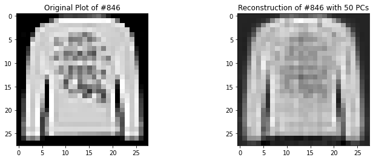

```python
# create a function that requires an argument n and plots a random image from the dataset, as well as a reconstruction with the first n-th principal components
import random

def project(W, X, mu):
    return np.dot(X - mu , W)

def reconstruct(W, Y, mu) :
    return np.dot(Y , W.T) + mu

def reconstruct_cloth(n):
    # set random number
    rad = random.choice(idx_cloth)
    # set fig
    plt.figure(figsize=(12, 4))
    # plot original
    plt.subplot(1, 2, 1)
    plt.imshow(x_cloth.loc[rad].values.reshape(28,28))
    plt.title('Original Plot of #{}'.format(rad))
    # plot reconstruct
    plt.subplot(1, 2, 2)
    mean = x_cloth.mean(axis=0)
    P = project(eigenVectors[:, 0:n], x_cloth.loc[rad], mean)
    R = reconstruct(eigenVectors[:, 0:n], P, mean)
    plt.imshow(R.values.reshape(28, 28), cmap = plt.cm.gray)
    plt.title('Reconstruction of #{} with {} PCs'.format(rad, n))
    plt.show()

reconstruct_cloth(50)
```

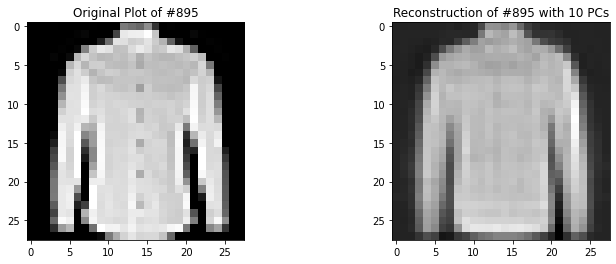

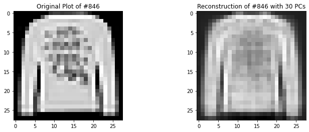

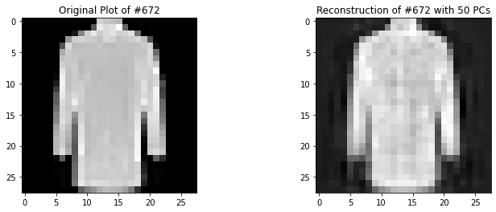

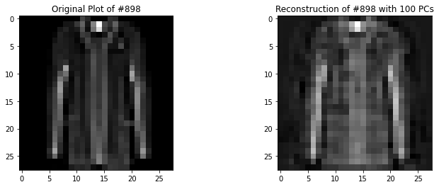

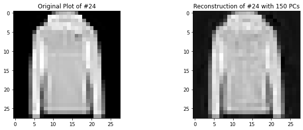

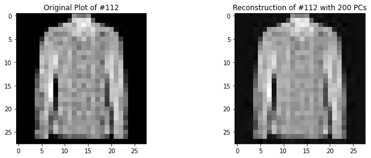

```python
recon_list = [10, 30, 50, 100, 150, 200]
for r in recon_list:
    reconstruct_cloth(r)
```

## Part 4.5: Answer

**Although we can see some patterns with few PCs(10-50), it is safer to make a guess at about 100 PCs as humans, because many clothes have intricate patterns on them. With smaller PC numbers we cannot identify those well.**

```python
x_cloth.shape
```

```
(281, 784)
```

## Part 4.6: Answer

The dataset we generated with only clothing has 281 samples and 784(28*28) pixel columns. Therefore:

- W: (784,784)
- Need 100 PCs, so W_op: (784, 100)
- Projection: X @ W_op = Proj(281, 100)
- Summarizing: Projection: (281,100) and W_op(784,100), so Total: 106500

Compression Ratio = 784*281/106500 = 2.07x

# References

Understanding PCA and SVD:

1. https://towardsdatascience.com/pca-and-svd-explained-with-numpy-5d13b0d2a4d8
2. https://stats.stackexchange.com/questions/134282/relationship-between-svd-and-pca-how-to-use-svd-to-perform-pca
3. https://stats.stackexchange.com/questions/2691/making-sense-of-principal-component-analysis-eigenvectors-eigenvalues
4. https://hadrienj.github.io/posts/Deep-Learning-Book-Series-2.8-Singular-Value-Decomposition/

PCA:

1. Snippets from: https://plot.ly/ipython-notebooks/principal-component-analysis/
2. https://www.value-at-risk.net/principal-component-analysis/

Covid Data:

1. https://www.worldometers.info/coronavirus/
2. https://datahub.io/core/covid-19#resource-time-series-19-covid-combined